# R Notebook - Bact-to-Batch PUBLICATION

A new method based on microbiota fingerprinting to guide animal allotments for animal experiments

```
## [1] "R version :  version.string R version 4.1.0 (2021-05-18)"
```

```
## [1] "Load packages"
```

# NAIVE APPROACH - CONSTAT

## CONSTAT - All solutions by ranking score

```
## [1] "Load the data.frame containing the 92378 results - Allotment 20 samples 2 groups"
```

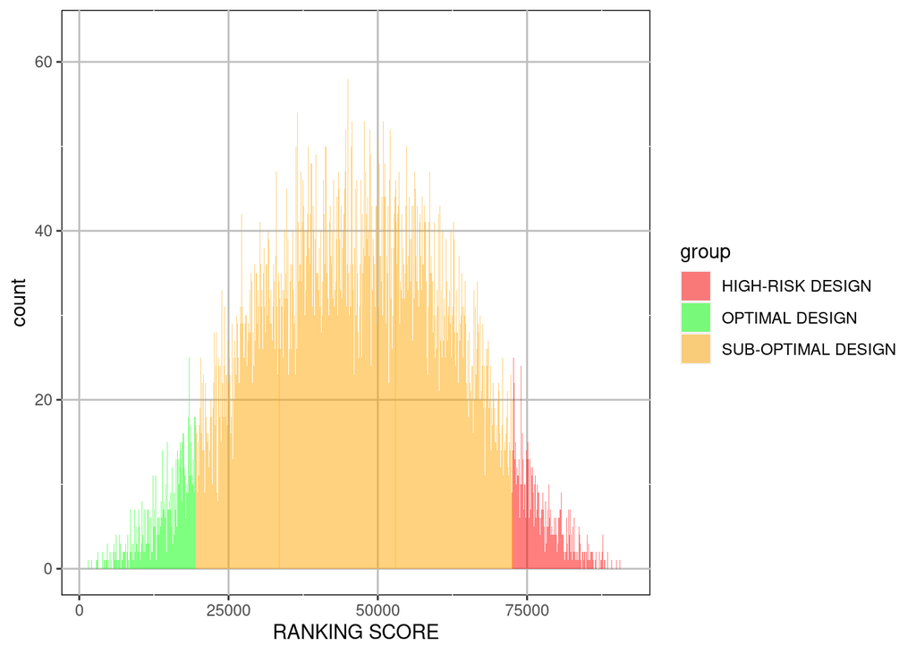

## CONSTAT - MAX HIGH-RISK RANKING SCORE FROM ALL POSSIBLE DESIGNS

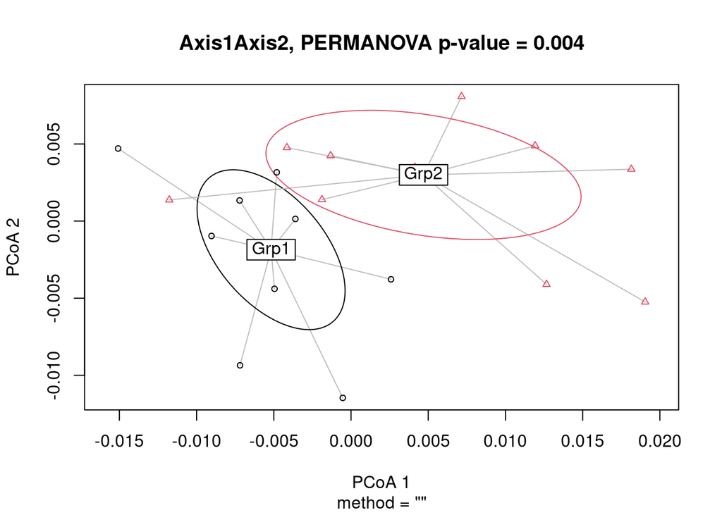

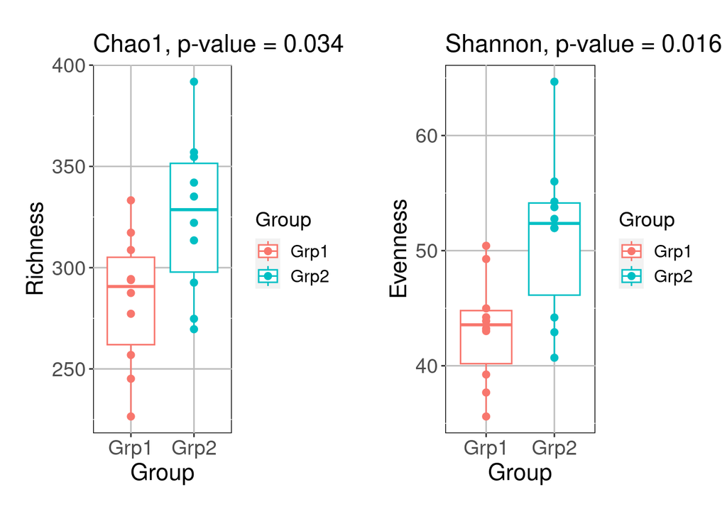

## CONSTAT - BEST RANKING SCORE FROM ALL POSSIBLE DESIGNS

Visualize the best ranking score.

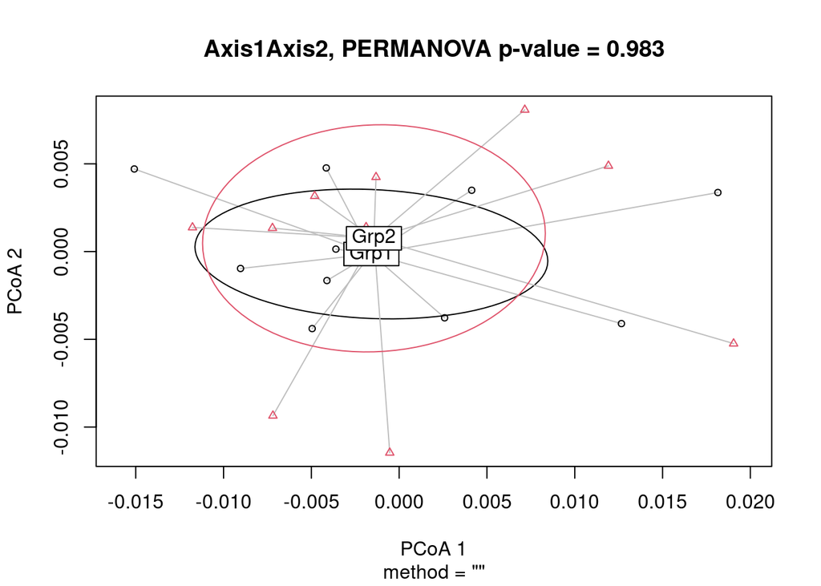

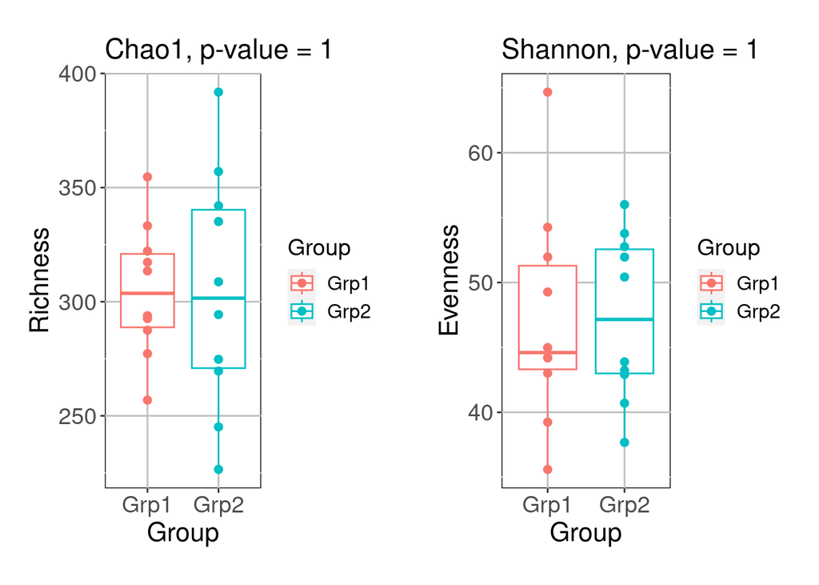

# HOW TO FIND THE BEST DESIGN ?

Ranking score is a trustable metric to get homogenous group. The naïve way to find the best design would be to compute all possible combinations and retain only the minimal ranking score.

Base on out first simulation, the computation time is exactly 60 minutes for 100 000 combinations.

We then simulate a few scenarios to estimate computation time for various design.

| n animals | n groups | n possible designs | CPU time (sec) | CPU time (year) |
| --- | --- | --- | --- | --- |
| 10 | 2 | 1.260000e+02 | 4.536000e+00 | 1.437372e-07 |
| 12 | 2 | 4.620000e+02 | 1.663200e+01 | 5.270363e-07 |
| 12 | 3 | 5.775000e+03 | 2.079000e+02 | 6.587953e-06 |
| 20 | 2 | 9.237800e+04 | 3.325608e+03 | 1.053822e-04 |
| 20 | 4 | 4.888644e+08 | 1.759912e+07 | 5.576824e-01 |
| 24 | 2 | 1.352078e+06 | 4.867481e+04 | 1.542412e-03 |
| 24 | 3 | 1.577585e+09 | 5.679307e+07 | 1.799664e+00 |
| 27 | 3 | 3.797891e+10 | 1.367241e+09 | 4.332524e+01 |
| 28 | 4 | 1.968826e+13 | 7.087775e+11 | 2.245980e+04 |
| 30 | 2 | 7.755876e+07 | 2.792115e+06 | 8.847680e-02 |

[output cut: 1 more lines]

There is no general formula for partitioning a vector into groups of equal size.

The number of possible ways to partition a vector depends on the length of the vector and the size of the groups.

As an illustration, The formula for calculating the number of ways to partition a vector into groups of equal size 2 is given by the following expression:

n! / (n / k)! * k^(n / k)

where n is the number of elements in the vector, k is the size of each group, and ! the factorial function.

Another way to approach this problem is to use generating functions, like the one propose by the R package RcppAlgos [ref].

For the experiment generated in the “constat”, it is of course possible to generate all the combinations in 1 hours and get the best result. But for more complex design, it becomes quickly impossible to wait for the generation of all results and get an exact best match.

We then develop an algorithm based on HillDiv diversity measurements and anticlustering technics to obtain a optimal results in a very quick way.

# AN OPTIMAL DESIGN TO REDUCE EXPERIMENTAL BIASES

## ALGORITHM VALIDATION ON ALLOTMENT RESULTS

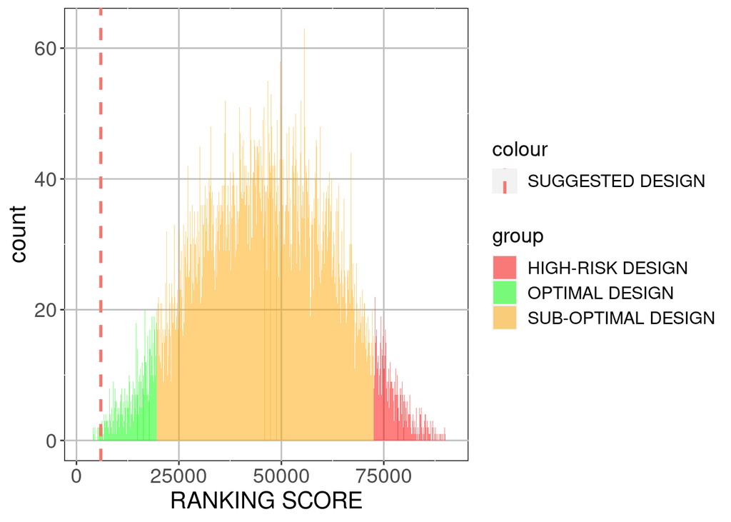

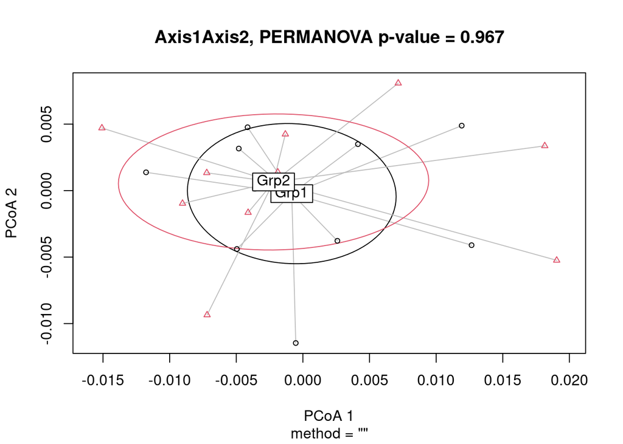

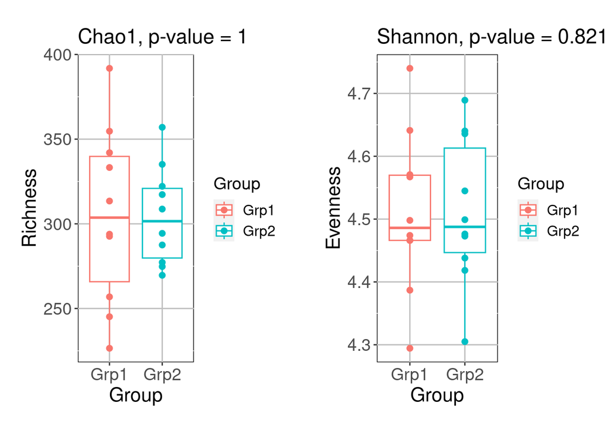

## ALGORITHM VALIDATION ON THIRD PARRY DATA (Neuman et al.)

### HISTOGRAM - 90000 RANDOMLY SIMULATING 90000 DESIGNS

```
## Loading objects:
##   tab_stats_combinaison_SRA_ALL
```

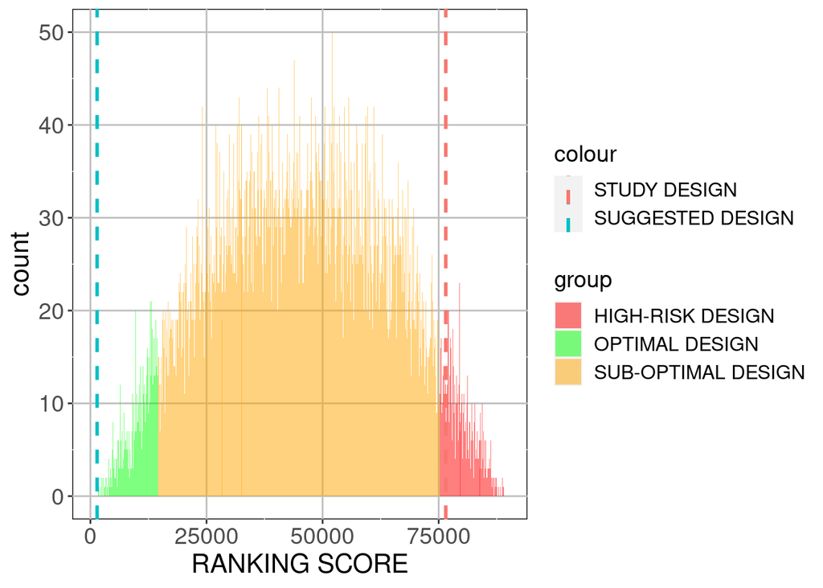

### ALPHA AND BETA DIVERSITIES VALIDATION ON BACT-TO-BATCH SUGGESTED DESIGN

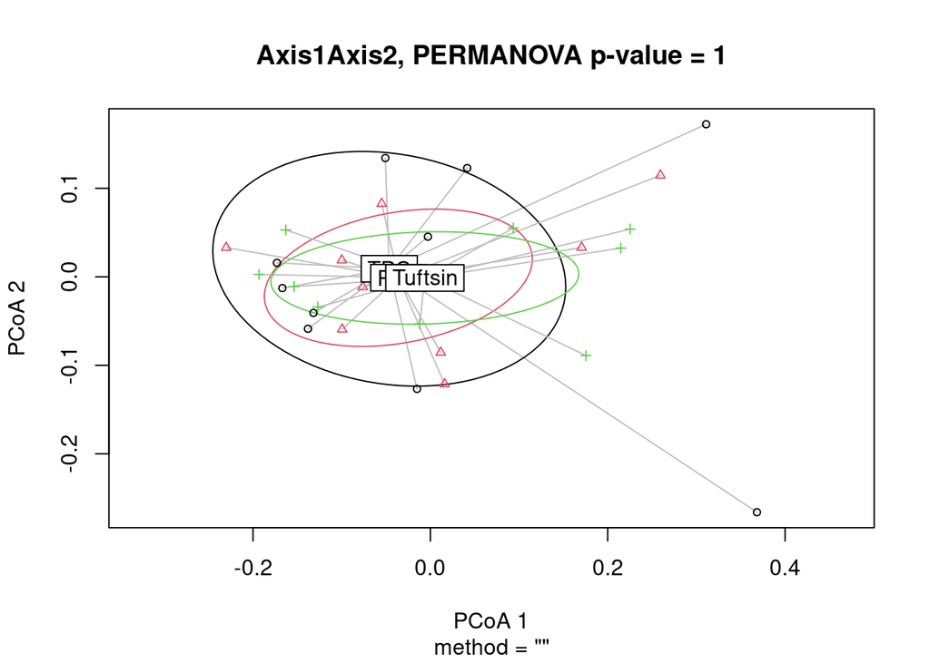

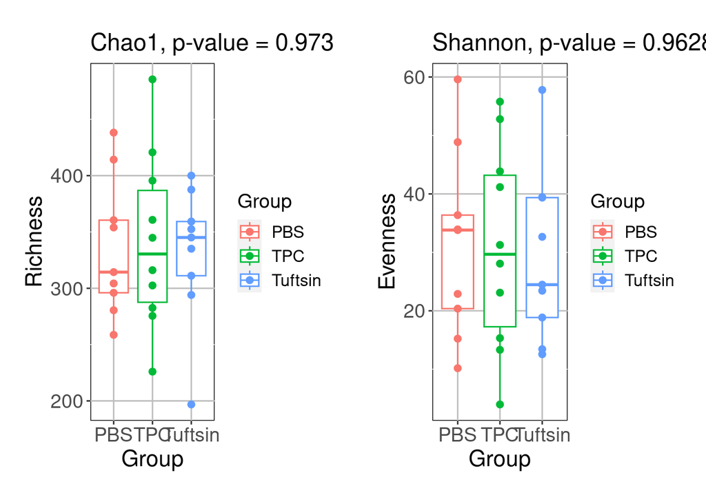

### ALPHA AND BETA DIVERSITIES VALIDATON ON STUDY DESIGN

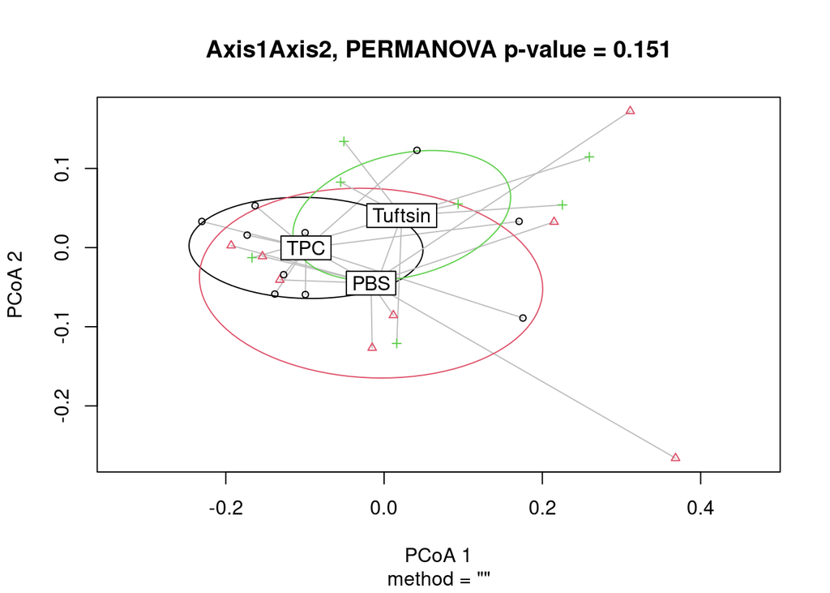

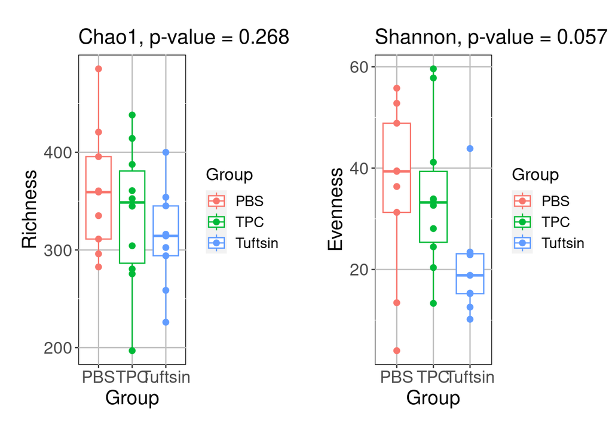